# Predictors of Heart Disease: Statistical Modeling and Testing

## 7 Model Building

Next, we begin the assembly of our regression model, speficially utilizing logistic regression.

### 7.1 Assumptions of Logistic Regression

1. **Binary Outcome Variable**: The dependent variable is binary.
2. **Independence of Observations**: Observations are independent of each other.
3. **Linearity of Logit**: The relationship between the predictors and the log-odds of the outcome is linear.
4. **No Multicollinearity**: Predictors are not highly correlated with each other.
5. **Large Sample Size**: Logistic regression works best with a large sample size to ensure reliable estimates.

*We will confirm these assumptions in the **Model Diagnostics and Validation** section below.*

### 7.2 Base Model

We begin with our base model, including all predictors:

```r
base_model <- glm(HeartDiseaseorAttack ~ ., data = heart_data, family = binomial)
summary(base_model)
```

```
Call:
glm(formula = HeartDiseaseorAttack ~ ., family = binomial, data = heart_data)

Coefficients:
                    Estimate Std. Error z value Pr(>|z|)
(Intercept)       -7.9124089  0.1028054 -76.965  < 2e-16 ***
HighBP             0.5245081  0.0177520  29.546  < 2e-16 ***
HighChol           0.6112677  0.0164496  37.160  < 2e-16 ***
CholCheck          0.5248111  0.0662510   7.922 2.35e-15 ***
BMI                0.0009744  0.0012122   0.804   0.4215
Smoker             0.3629524  0.0157323  23.071  < 2e-16 ***
Stroke             0.9783443  0.0244338  40.041  < 2e-16 ***
Diabetes           0.1465123  0.0089720  16.330  < 2e-16 ***
PhysActivity       0.0398975  0.0171991   2.320   0.0204 *
Fruits             0.0060203  0.0163274   0.369   0.7123
Veggies            0.0426327  0.0189359   2.251   0.0244 *
HvyAlcoholConsump -0.2940714  0.0392877  -7.485 7.15e-14 ***
AnyHealthcare     -0.0070009  0.0412820  -0.170   0.8653
NoDocbcCost        0.2528463  0.0268896   9.403  < 2e-16 ***
GenHlth            0.4907058  0.0095105  51.596  < 2e-16 ***
MentHlth           0.0024628  0.0009778   2.519   0.0118 *
PhysHlth           0.0010542  0.0008766   1.202   0.2292
DiffWalk           0.2947780  0.0193855  15.206  < 2e-16 ***
Sex                0.7611811  0.0160326  47.477  < 2e-16 ***
Age                0.2556493  0.0036439  70.158  < 2e-16 ***
Education          0.0110314  0.0081696   1.350   0.1769
Income            -0.0431551  0.0042476 -10.160  < 2e-16 ***
---
Signif. codes:  0 '***' 0.001 '**' 0.01 '*' 0.05 '.' 0.1 ' ' 1

(Dispersion parameter for binomial family taken to be 1)

    Null deviance: 158355  on 253679  degrees of freedom
Residual deviance: 120933  on 253658  degrees of freedom
AIC: 120977

Number of Fisher Scoring iterations: 6
```

```r
stepwise_model <- stepAIC(base_model, direction = "both", trace = FALSE)
summary(stepwise_model)
```

```
Call:
glm(formula = HeartDiseaseorAttack ~ HighBP + HighChol + CholCheck +
    Smoker + Stroke + Diabetes + PhysActivity + Veggies + HvyAlcoholConsump +
    NoDocbcCost + GenHlth + MentHlth + DiffWalk + Sex + Age +
    Income, family = binomial, data = heart_data)

Coefficients:
                   Estimate Std. Error z value Pr(>|z|)
(Intercept)       -7.849811   0.084630 -92.755  < 2e-16 ***
HighBP             0.525327   0.017568  29.902  < 2e-16 ***
HighChol           0.611535   0.016439  37.201  < 2e-16 ***
CholCheck          0.525554   0.066050   7.957 1.76e-15 ***
Smoker             0.360912   0.015659  23.048  < 2e-16 ***
Stroke             0.978517   0.024405  40.096  < 2e-16 ***
Diabetes           0.147432   0.008805  16.745  < 2e-16 ***
PhysActivity       0.039919   0.017008   2.347  0.01892 *
Veggies            0.046723   0.018425   2.536  0.01122 *
HvyAlcoholConsump -0.295596   0.039239  -7.533 4.95e-14 ***
NoDocbcCost        0.254267   0.026437   9.618  < 2e-16 ***
GenHlth            0.494177   0.008690  56.866  < 2e-16 ***
MentHlth           0.002741   0.000954   2.873  0.00406 **
DiffWalk           0.302854   0.018630  16.256  < 2e-16 ***
Sex                0.761142   0.015982  47.626  < 2e-16 ***
Age                0.254982   0.003500  72.862  < 2e-16 ***
Income            -0.040995   0.003938 -10.410  < 2e-16 ***
---
Signif. codes:  0 '***' 0.001 '**' 0.01 '*' 0.05 '.' 0.1 ' ' 1

(Dispersion parameter for binomial family taken to be 1)

    Null deviance: 158355  on 253679  degrees of freedom
Residual deviance: 120937  on 253663  degrees of freedom
AIC: 120971

Number of Fisher Scoring iterations: 6
```

*Note: We have omitted the full stepwise regression output from this report to ensure smoother rendering and reduce processing times.*

Looking at the summary of the logistic regression model with all variables, it appears that the predictors `BMI`, `Fruits`, `AnyHealthcare`, `PhysHlth`**,** and `Education` have p-values over 0.05, indicating insignificance to the model.

A stepwise selection process in both directions was used to select the best model by using AIC to identify the most significant factors. This selection method combines **forward selection** and **backward elimination.**

The model resulted in the inclusion of the following predictors as most significant:

- **HighBP**
- **HighChol**
- **CholCheck**
- **Smoker**
- **Stroke**
- **Diabetes**
- **PhysActivity**
- **Veggies**
- **HvyAlcoholConsump**
- **NoDocbcCost**
- **GenHlth**
- **MentHlth**
- **DiffWalk**
- **Sex**
- **Age**
- **Income**

The selection process included 6 iterations, removing the predictors `BMI`, `Fruits`, `AnyHealthcare`, `PhysHlth`**,** and `Education` from the full model as they did not significantly contribute to the model’s fit according to the AIC.

#### 7.2.1 Summary

As detailed above, the final model based on our stepwise selection process is as follows:

```r
# Model after stepwise selection
final_model <- glm(HeartDiseaseorAttack ~ HighBP + HighChol + CholCheck + Smoker +
                     Stroke + Diabetes + PhysActivity + Veggies + HvyAlcoholConsump +
                     NoDocbcCost + GenHlth + MentHlth + DiffWalk + Sex + Age +
                     Income, data = heart_data, family = binomial)
```

## 8 Model Diagnostics and Validation

Let us now confirm that the assumptions of logistic regression in our model:

### 8.1 Binary Outcome Variable

The dependent variable is `HeartDiseaseorAttack`, which has values: **0 = No, 1 = Yes**

This variable is binary and confirms this assumption.

### 8.2 Independence

In our dataset, each observation represents a unique individual, and there are no repeated measures or clustering effects. Therefore, the independence assumption is confirmed.

### 8.3 Linearity of Logit

The age variable is categorized into groups, making it more complex to analyze in logistic regression. Our attempts to test its linearity caused technical issues with the model, so keep the analysis straightforward, we left the variable as is. Accurate assessment of this assumption may require a more thorough refining of the age variable, be it through transformations or other means.

### 8.4 No Multicollinearity

```r
# Checking for multicollinearity via the Variance Inflation Factor (VIF)
vif_values <- vif(final_model)
print("Variance Inflation Factor (VIF) values:")
```

```
[1] "Variance Inflation Factor (VIF) values:"
```

```r
print(vif_values)
```

```
           HighBP          HighChol         CholCheck            Smoker
         1.118635          1.060904          1.013787          1.041327
           Stroke          Diabetes      PhysActivity           Veggies
         1.033980          1.105517          1.131639          1.044400
HvyAlcoholConsump       NoDocbcCost           GenHlth          MentHlth
         1.017747          1.129484          1.526453          1.235811
         DiffWalk               Sex               Age            Income
         1.392603          1.110160          1.140386          1.311509
```

Based on the details outlines above, the Variance Inflation Factor (VIF) values indicate that there are no concerning multicollinearity issues present in our final model. Generally, VIF values below 5 (sometimes 10 for larger datasets) suggest that predictors are not highly correlated.

### 8.5 Cook’s Distance

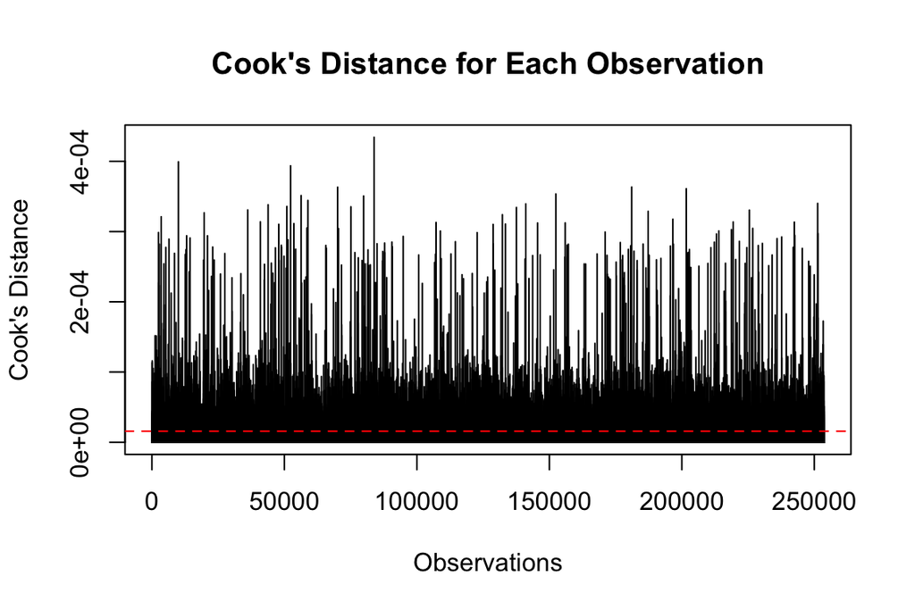

```r
# Checking for influential points via Cook's Distance plot
cooks_d <- cooks.distance(stepwise_model)
cook_thresh <- 4 / nrow(heart_data)
plot(cooks_d, type = "h", main = "Cook's Distance for Each Observation",
     ylab = "Cook's Distance", xlab = "Observations")
abline(h = cook_thresh, col = "red", lty = 2)
```

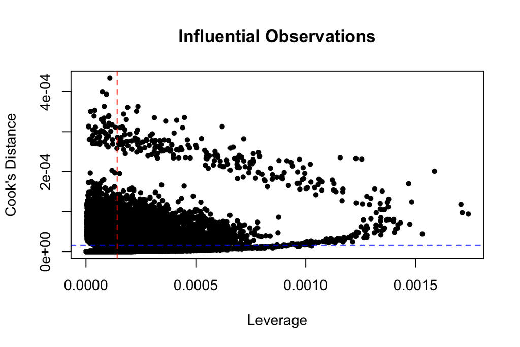

```r
# Checking for influential points via leverage plot
leverage <- hatvalues(stepwise_model)
leverage_thresh <- 2 * (length(coef(stepwise_model)) + 1) / nrow(heart_data)
plot(leverage, cooks_d, xlab = "Leverage", ylab = "Cook's Distance",
     main = "Influential Observations", pch = 20, col = "black")
abline(h = cook_thresh, col = "blue", lty = 2)
abline(v = leverage_thresh, col = "red", lty = 2)
```

Based on both the Cooks Distance and Leverage plots, we can see that no single observation appears to be excessively influential, indicating that the model is robust. Given that no significant outliers have been identified, we will not be removing any observations from the model.

### 8.6 Large Sample Size

Given that our dataset containts over 250,000 observations, the assumption of large sample size is met.

### 8.7 Interaction Terms

In an effort to describe the model in the most detail possible, we will also include the following interaction terms:

- HighBP × HighChol
- HighBP × Smoker
- HighChol × Stroke
- Smoker × Stroke
- Stroke × GenHlth
- GenHlth × Age
- PhysActivity × Veggies
- HvyAlcoholConsump × NoDocbcCost

```r
# Outlining the interaction model
interaction_model <- glm(
  HeartDiseaseorAttack ~ HighBP * HighChol +
    HighBP * Smoker +
    HighChol * Stroke +
    Smoker * Stroke +
    Stroke * GenHlth +
    GenHlth * Age +
    PhysActivity * Veggies +
    HvyAlcoholConsump * NoDocbcCost +
    HighBP + HighChol + Smoker + Stroke + GenHlth + PhysActivity + Veggies +
    HvyAlcoholConsump + NoDocbcCost + GenHlth + MentHlth + DiffWalk +
    Sex + Age + Income + CholCheck + Diabetes,
  data = heart_data,
  family = binomial
)

# Printing a summary of the interaction model
summary(interaction_model)
```

```
Call:
glm(formula = HeartDiseaseorAttack ~ HighBP * HighChol + HighBP *
    Smoker + HighChol * Stroke + Smoker * Stroke + Stroke * GenHlth +
    GenHlth * Age + PhysActivity * Veggies + HvyAlcoholConsump *
    NoDocbcCost + HighBP + HighChol + Smoker + Stroke + GenHlth +
    PhysActivity + Veggies + HvyAlcoholConsump + NoDocbcCost +
    GenHlth + MentHlth + DiffWalk + Sex + Age + Income + CholCheck +
    Diabetes, family = binomial, data = heart_data)

Coefficients:
                                Estimate Std. Error z value Pr(>|z|)
(Intercept)                   -9.0547531  0.1325791 -68.297  < 2e-16 ***
HighBP                         0.4907252  0.0332683  14.751  < 2e-16 ***
HighChol                       0.5700414  0.0284349  20.047  < 2e-16 ***
Smoker                         0.4259475  0.0290007  14.687  < 2e-16 ***
Stroke                         1.5480487  0.0905713  17.092  < 2e-16 ***
GenHlth                        0.8676025  0.0325858  26.625  < 2e-16 ***
Age                            0.3697799  0.0106097  34.853  < 2e-16 ***
PhysActivity                   0.0712664  0.0320648   2.223 0.026245 *
Veggies                        0.0710875  0.0282127   2.520 0.011746 *
HvyAlcoholConsump             -0.3192760  0.0417302  -7.651 1.99e-14 ***
NoDocbcCost                    0.2205944  0.0269747   8.178 2.89e-16 ***
MentHlth                       0.0015246  0.0009568   1.593 0.111079
DiffWalk                       0.3023440  0.0185343  16.313  < 2e-16 ***
Sex                            0.7559528  0.0159463  47.406  < 2e-16 ***
Income                        -0.0373180  0.0039367  -9.479  < 2e-16 ***
CholCheck                      0.5193762  0.0661194   7.855 3.99e-15 ***
Diabetes                       0.1442157  0.0087666  16.451  < 2e-16 ***
HighBP:HighChol                0.1279302  0.0346383   3.693 0.000221 ***
HighBP:Smoker                 -0.0884719  0.0339417  -2.607 0.009145 **
HighChol:Stroke               -0.4416252  0.0507694  -8.699  < 2e-16 ***
Smoker:Stroke                 -0.1004807  0.0485797  -2.068 0.038605 *
Stroke:GenHlth                -0.0585123  0.0225713  -2.592 0.009533 **
GenHlth:Age                   -0.0367094  0.0031181 -11.773  < 2e-16 ***
PhysActivity:Veggies          -0.0447662  0.0368020  -1.216 0.223830
HvyAlcoholConsump:NoDocbcCost  0.1921910  0.1206683   1.593 0.111223
---
Signif. codes:  0 '***' 0.001 '**' 0.01 '*' 0.05 '.' 0.1 ' ' 1

(Dispersion parameter for binomial family taken to be 1)

    Null deviance: 158355  on 253679  degrees of freedom
Residual deviance: 120680  on 253655  degrees of freedom
AIC: 120730

Number of Fisher Scoring iterations: 7
```

Next we will perform the stepwise selection again, this timem focusing on the new interaction model:

```r
# Outlining the stepwise selection for the new interaction model
stepwise_interaction_model <- stepAIC(interaction_model, direction = "both", trace = FALSE)

# Printing a summary
summary(stepwise_interaction_model)
```

```
Call:
glm(formula = HeartDiseaseorAttack ~ HighBP + HighChol + Smoker +
    Stroke + GenHlth + Age + PhysActivity + Veggies + HvyAlcoholConsump +
    NoDocbcCost + MentHlth + DiffWalk + Sex + Income + CholCheck +
    Diabetes + HighBP:HighChol + HighBP:Smoker + HighChol:Stroke +
    Smoker:Stroke + Stroke:GenHlth + GenHlth:Age + HvyAlcoholConsump:NoDocbcCost,
    family = binomial, data = heart_data)

Coefficients:
                                Estimate Std. Error z value Pr(>|z|)
(Intercept)                   -9.0374608  0.1318007 -68.569  < 2e-16 ***
HighBP                         0.4908139  0.0332682  14.753  < 2e-16 ***
HighChol                       0.5700173  0.0284345  20.047  < 2e-16 ***
Smoker                         0.4261185  0.0290001  14.694  < 2e-16 ***
Stroke                         1.5486694  0.0905683  17.099  < 2e-16 ***
GenHlth                        0.8678146  0.0325848  26.632  < 2e-16 ***
Age                            0.3697842  0.0106094  34.854  < 2e-16 ***
PhysActivity                   0.0381591  0.0169391   2.253 0.024276 *
Veggies                        0.0450789  0.0183618   2.455 0.014087 *
HvyAlcoholConsump             -0.3195208  0.0417301  -7.657 1.91e-14 ***
NoDocbcCost                    0.2203268  0.0269749   8.168 3.14e-16 ***
MentHlth                       0.0015095  0.0009568   1.578 0.114632
DiffWalk                       0.3025022  0.0185347  16.321  < 2e-16 ***
Sex                            0.7562402  0.0159439  47.431  < 2e-16 ***
Income                        -0.0373760  0.0039367  -9.494  < 2e-16 ***
CholCheck                      0.5192716  0.0661177   7.854 4.04e-15 ***
Diabetes                       0.1442449  0.0087667  16.454  < 2e-16 ***
HighBP:HighChol                0.1280530  0.0346379   3.697 0.000218 ***
HighBP:Smoker                 -0.0886864  0.0339409  -2.613 0.008976 **
HighChol:Stroke               -0.4416122  0.0507695  -8.698  < 2e-16 ***
Smoker:Stroke                 -0.1000196  0.0485779  -2.059 0.039499 *
Stroke:GenHlth                -0.0587523  0.0225704  -2.603 0.009239 **
GenHlth:Age                   -0.0367077  0.0031181 -11.773  < 2e-16 ***
HvyAlcoholConsump:NoDocbcCost  0.1913418  0.1206844   1.585 0.112859
---
Signif. codes:  0 '***' 0.001 '**' 0.01 '*' 0.05 '.' 0.1 ' ' 1

(Dispersion parameter for binomial family taken to be 1)

    Null deviance: 158355  on 253679  degrees of freedom
Residual deviance: 120681  on 253656  degrees of freedom
AIC: 120729

Number of Fisher Scoring iterations: 7
```

*Note: We have omitted the full stepwise regression output from this report to ensure smoother rendering and reduce processing times.*

As shown through the stepwise selection process above, we have arrived at a logistic regression model that aims to predicts the likelihood of heart disease. This model is based on the significant predictors from our first final model, as well as interactions between key variables. Below is a summary of the model’s components:

```r
# Outlining the final model
final_interaction_model <- glm(formula = HeartDiseaseorAttack ~ HighBP + HighChol + Smoker + Stroke + GenHlth + Age + PhysActivity + Veggies + HvyAlcoholConsump +
    NoDocbcCost + MentHlth + DiffWalk + Sex + Income + CholCheck +
    Diabetes + HighBP:HighChol + HighBP:Smoker + HighChol:Stroke +
    Smoker:Stroke + Stroke:GenHlth + GenHlth:Age + HvyAlcoholConsump:NoDocbcCost,
    family = binomial, data = heart_data)

# Printing a summary of the final model
summary(final_interaction_model)
```

```
Call:
glm(formula = HeartDiseaseorAttack ~ HighBP + HighChol + Smoker +
    Stroke + GenHlth + Age + PhysActivity + Veggies + HvyAlcoholConsump +
    NoDocbcCost + MentHlth + DiffWalk + Sex + Income + CholCheck +
    Diabetes + HighBP:HighChol + HighBP:Smoker + HighChol:Stroke +
    Smoker:Stroke + Stroke:GenHlth + GenHlth:Age + HvyAlcoholConsump:NoDocbcCost,
    family = binomial, data = heart_data)

Coefficients:
                                Estimate Std. Error z value Pr(>|z|)
(Intercept)                   -9.0374608  0.1318007 -68.569  < 2e-16 ***
HighBP                         0.4908139  0.0332682  14.753  < 2e-16 ***
HighChol                       0.5700173  0.0284345  20.047  < 2e-16 ***
Smoker                         0.4261185  0.0290001  14.694  < 2e-16 ***
Stroke                         1.5486694  0.0905683  17.099  < 2e-16 ***
GenHlth                        0.8678146  0.0325848  26.632  < 2e-16 ***
Age                            0.3697842  0.0106094  34.854  < 2e-16 ***
PhysActivity                   0.0381591  0.0169391   2.253 0.024276 *
Veggies                        0.0450789  0.0183618   2.455 0.014087 *
HvyAlcoholConsump             -0.3195208  0.0417301  -7.657 1.91e-14 ***
NoDocbcCost                    0.2203268  0.0269749   8.168 3.14e-16 ***
MentHlth                       0.0015095  0.0009568   1.578 0.114632
DiffWalk                       0.3025022  0.0185347  16.321  < 2e-16 ***
Sex                            0.7562402  0.0159439  47.431  < 2e-16 ***
Income                        -0.0373760  0.0039367  -9.494  < 2e-16 ***
CholCheck                      0.5192716  0.0661177   7.854 4.04e-15 ***
Diabetes                       0.1442449  0.0087667  16.454  < 2e-16 ***
HighBP:HighChol                0.1280530  0.0346379   3.697 0.000218 ***
HighBP:Smoker                 -0.0886864  0.0339409  -2.613 0.008976 **
HighChol:Stroke               -0.4416122  0.0507695  -8.698  < 2e-16 ***
Smoker:Stroke                 -0.1000196  0.0485779  -2.059 0.039499 *
Stroke:GenHlth                -0.0587523  0.0225704  -2.603 0.009239 **
GenHlth:Age                   -0.0367077  0.0031181 -11.773  < 2e-16 ***
HvyAlcoholConsump:NoDocbcCost  0.1913418  0.1206844   1.585 0.112859
---
Signif. codes:  0 '***' 0.001 '**' 0.01 '*' 0.05 '.' 0.1 ' ' 1

(Dispersion parameter for binomial family taken to be 1)

    Null deviance: 158355  on 253679  degrees of freedom
Residual deviance: 120681  on 253656  degrees of freedom
AIC: 120729

Number of Fisher Scoring iterations: 7
```

#### 8.7.2 **Interaction Terms**

Detailed below are the significant interaction effects:

1. **HighBP** (p=0.0002): The combined presence of high blood pressure and high cholesterol has a multiplicative effect, increasing the odds of heart disease.
2. **HighBP** (p=0.009): Smoking interacts with high blood pressure to slightly reduce the risk compared to their independent effects.
3. **HighChol** (p<0.001): High cholesterol’s effect on heart disease risk is mitigated for those with a history of stroke.
4. **Smoker** (p=0.039): Smoking combined with a stroke history slightly reduces the risk compared to their independent effects.
5. **Stroke** (p=0.009): Poor general health modifies the effect of having a stroke on heart disease risk.
6. **GenHlth** (p<0.001): Age modifies the effect of general health on heart disease risk.

## 9 Predictive Model Outputs and Interpretation

Now, let us outline key outputs from the final logistic regression model, including odds ratios, ROC and calibration curves. This will help us to evaluate the model’s predictive performance and provide insights into the factors influencing heart disease, helping us ensure the model’s results are interpretable and aligned with our research objectives.

### 9.1 Odds Ratio

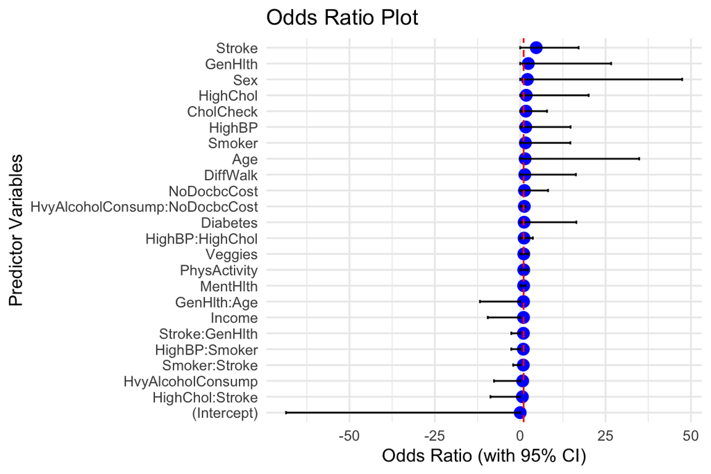

```r
# odds ratios and confidence intervals
model_summary <- tidy(final_interaction_model, exponentiate = TRUE, conf.int = TRUE)

colnames(model_summary) <- c("Variable", "OddsRatio", "StdError", "ConfLow", "ConfHigh", "PValue")

# odds ratio plot
ggplot(model_summary, aes(x = reorder(Variable, OddsRatio), y = OddsRatio)) +
  geom_point(size = 3, color = "blue") +
  geom_errorbar(aes(ymin = ConfLow, ymax = ConfHigh), width = 0.2) +
  geom_hline(yintercept = 1, linetype = "dashed", color = "red") +
  coord_flip() +
  labs(
    title = "Odds Ratio Plot",
    x = "Predictor Variables",
    y = "Odds Ratio (with 95% CI)"
  ) +
  theme_minimal()
```

```r
# Outlining interpreations of the odds ratio in a table for compactness
predictors_table <- data.frame(
  Predictor = c(
    "HighBP", "HighChol", "Smoker",
    "Stroke", "GenHlth", "Age", "DiffWalk",
    "Income", "CholCheck", "PhysActivity",
    "Veggies", "HvyAlcoholConsump",
    "Diabetes", "Sex", "NoDocbcCost",
    "HighBP × HighChol", "HighBP × Smoker", "HighChol × Stroke",
    "Smoker × Stroke", "Stroke × GenHlth", "GenHlth × Age"
  ),
  Coefficient = c(
    0.491, 0.570, 0.426, 1.549, 0.868, 0.370, 0.303,
    -0.037, 0.519, 0.038, 0.045, -0.320, 0.144, 0.756, 0.220,
    0.128, -0.089, -0.442, -0.100, -0.059, -0.037
  ),
  OddsRatio = c(
    1.63, 1.77, 1.53, 4.71, 2.38, 1.45, 1.35,
    0.96, 1.68, 1.04, 1.05, 0.73, 1.15, 2.13, 1.25,
    1.14, 0.91, 0.64, 0.90, 0.94, 0.96
  ),
  Interpretation = c(
    "High blood pressure increases the odds of heart disease by 63%",
    "High cholesterol raises the odds of heart disease by 77%",
    "Smokers are 53% more likely to have heart disease",
    "A history of stroke increases the likelihood of heart disease by 371%",
    "Poorer general health increases heart disease risk by 138%",
    "Moving to the next age group increases heart disease odds by 45%",
    "Individuals with mobility issues are 35% more likely to have heart disease",
    "Higher income levels are slightly protective against heart disease",
    "Recent cholesterol screening is associated with a 68% higher likelihood of identifying heart disease",
    "Slight increase in risk; likely due to other confounding health behaviors",
    "Associated with a minor protective effect",
    "Heavy alcohol consumption reduces odds, but this result may reflect underlying health or reporting biases",
    "Diabetes increases the odds of heart disease by 15%",
    "Males have over twice the odds of heart disease compared to females",
    "Inability to afford medical care increases heart disease odds by 25%",
    "Combined presence of high blood pressure and high cholesterol increases odds by 14% over their independent effects",
    "Smoking slightly offsets the risk of high blood pressure on heart disease, potentially due to competing risks",
    "The effect of high cholesterol is lessened for those with a history of stroke",
    "The combined effect of smoking and stroke history is slightly less than their individual effects",
    "Poor general health slightly reduces the stroke effect on heart disease risk",
    "As individuals age, the impact of general health on heart disease slightly diminishes"
  )
)

# Generating the the table
library(knitr)
kable(
  predictors_table,
  col.names = c("Predictor", "Coefficient", "Odds Ratio", "Interpretation"),
  caption = "Summary of Predictors, Interaction Terms, and Odds Ratios"
)
```

Summary of Predictors, Interaction Terms, and Odds Ratios

[output not shown]

### 9.2 ROC Curve

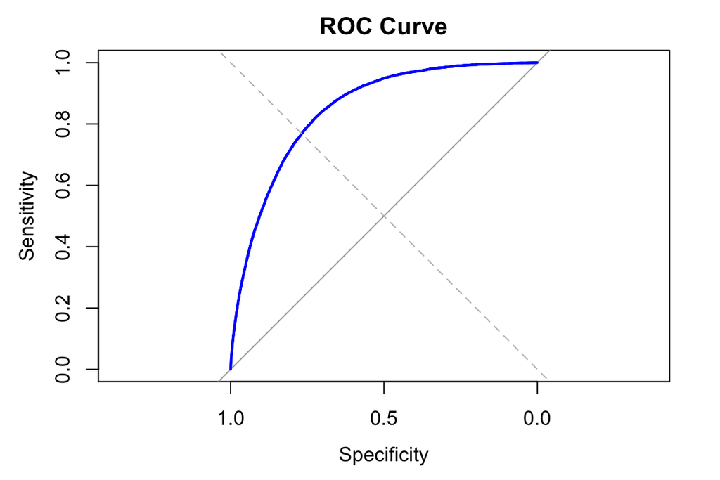

```r
# ROC curve code:

# Predicted probabilities from final model
predicted_probs <- predict(final_interaction_model, heart_data, type = "response")

# Actual outcomes
actual_outcomes <- as.numeric(heart_data$HeartDiseaseorAttack) # EDIT: Converted to numeric to ensure compatibility with `roc()` function.

# ROC curve
roc_curve <- roc(actual_outcomes, predicted_probs)

# ROC curve plot
plot(roc_curve, main = "ROC Curve", col = "blue", lwd = 2)
abline(a = 0, b = 1, lty = 2, col = "gray") # Diagonal reference line
```

```r
# AUC
auc_value <- auc(roc_curve)
cat("Area Under the Curve (AUC):", auc_value, "\n")
```

```
Area Under the Curve (AUC): 0.8475062
```

An AUC of 0.8475 suggests that the model has good discriminatory power, meaning it can effectively separate individuals with and without the outcome (heart disease).

### 9.3 Calibration Curve

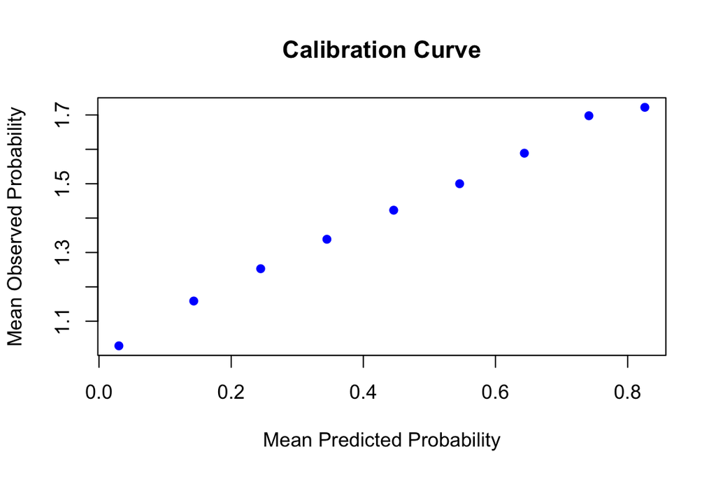

```r
# Calibration curve code:

# Grouping predicted probabilities
calibration_data <- data.frame(
  predicted_probs = predicted_probs,
  actual_outcomes = actual_outcomes
)
calibration_data$bin <- cut(
  calibration_data$predicted_probs,
  breaks = seq(0, 1, by = 0.1),
  include.lowest = TRUE
)

# Mean predicted probabilities and observed outcomes in each bin
calibration_summary <- calibration_data %>%
  group_by(bin) %>%
  summarise(
    mean_predicted = mean(predicted_probs, na.rm = TRUE), # EDIT: Added `na.rm = TRUE` to handle potential NAs in predicted probabilities.
    mean_observed = mean(actual_outcomes, na.rm = TRUE)  # EDIT: Added `na.rm = TRUE` to handle potential NAs in observed outcomes.
  )

# Calibration curve plot
plot(
  calibration_summary$mean_predicted,
  calibration_summary$mean_observed,
  xlab = "Mean Predicted Probability",
  ylab = "Mean Observed Probability",
  main = "Calibration Curve",
  col = "blue",
  pch = 16
)
abline(0, 1, lty = 2, col = "gray")
```

## 10 Summary: Research Question and Hypotheses

The analysis sought to identify significant predictors of heart disease. Our hypothesis was supported: **age**, **smoking**, **high blood pressure**, and **stroke** are strongly associated with increased odds of heart disease. Factors like **cholesterol**, **general health**, and socioeconomic indicators like **income** also play critical roles.